# WCS-SD

Jordan Lee

3/6/2020

# Purpose

Updated on 5/20/20 with outputs from Kallisto for bulk RNA processing

Notebook will showcase the comparisons we are interested in presenting at the Gray Group presentations on May 21, 2020.

# Analysis Preprocessing

```r
# Disclaimer: hardcoded names of patients in flat_matrix
# hard coded condition vector
####################
file_bulk_all <- '/Users/leejor/Ellrott_Lab/04_CSBC/cell-dissociation/data/01_process-bulkrna/06_matrices_postkallisto/Datan.txt'

countsMECH_1_matrix_dir <- '/Users/leejor/Ellrott_Lab/04_CSBC/cell-dissociation/data/02_process-scrna/7319_Mech/'
countsENZ_1_matrix_dir <- '/Users/leejor/Ellrott_Lab/04_CSBC/cell-dissociation/data/02_process-scrna/7319_Enz/'
countsMECH_2_matrix_dir <- '/Users/leejor/Ellrott_Lab/04_CSBC/cell-dissociation/data/02_process-scrna/7320_Mech/'
countsENZ_2_matrix_dir <- '/Users/leejor/Ellrott_Lab/04_CSBC/cell-dissociation/data/02_process-scrna/7320_Enz/'
THRES = 0.01
output_sortedGenes = '/Users/leejor/Ellrott_Lab/04_CSBC/cell-dissociation/data/03_compare-bulk_scrna/scrna2bulk/geneOrdered_results.csv'

# bulk_base_names <- c('bulk_7319', 'bulk_7320')
# bulkgt_base_names <- c('bulkGT_7319', 'bulkGT_7320')
# bulknorm_base_names <- c('bulk_norm_7319', 'bulk_norm_7320')
scmech_base_names <- c('sc_mech_7319', 'sc_mech_7320')
scenz_base_names <- c('sc_enz_7319', 'sc_enz_7320')
####################
```

```r
library(Seurat)
library(dplyr)
library(Matrix)
library(gdata)
library(DESeq2)
```

```r
library(ggplot2)
library(pheatmap)
library(vsn)
library(RColorBrewer)
library(readr)
library(tibble)
library(tidyverse)
library(ggrepel)
```

# Create combined matrices of mech and enz

Read in files and create pseudo-bulk (take the sum of raw gene counts across all cell barcodes and report that as the pseudo-bulk gene count). Preprocessing steps shown in `.Rmd`

```r
###############################
# Create combined count matrices
###############################
# Read in files
counts_mech1 <- Read10X(data.dir = countsMECH_1_matrix_dir, gene.column = 2)
counts_enz1 <- Read10X(data.dir = countsENZ_1_matrix_dir, gene.column = 2)
counts_mech2 <- Read10X(data.dir = countsMECH_2_matrix_dir,gene.column = 2)
counts_enz2 <- Read10X(data.dir = countsENZ_2_matrix_dir, gene.column = 2)
# convert to dense matrix
counts_mech1 <- as.matrix(counts_mech1)
counts_enz1 <- as.matrix(counts_enz1)
counts_mech2 <- as.matrix(counts_mech2)
counts_enz2 <- as.matrix(counts_enz2)
# Flaten counts (sum all cells for a gene) + combine matrices
mech1 <- as.data.frame(rowSums(counts_mech1))
enz1 <- as.data.frame(rowSums(counts_enz1))
mech2 <- as.data.frame(rowSums(counts_mech2))
enz2 <- as.data.frame(rowSums(counts_enz2))
```

```r
########################
# Read in bulk samples and create a unified count matrix
########################
# Bulk
b1 <- read.table(file=file_bulk_all , sep='\t', header=TRUE)
colnames(b1)[1]<- 'gene'
```

# Part 1: bulk GT vs bulk B

### A. Condition only affects

An analysis we can’t run is split by patient for bulk gt vs bulk b - because we must have at least a sample size of 2 for each condition. `The design matrix has the same number of samples and coefficients to fit, so estimation of dispersion is not possible.`

If we still want to investigate this trend we can only compare bulk gt vs bulk b when we group together patients and this analysis is included in this section.

```r
############################
# Create count matrices for DGE
############################
# Grab only samples of interest
flat_matrix_ctrlBULK <- b1[,c("SCC_7319_B2","SCC_7319_GT","SCC_7320_B2","SCC_7320_GT")]
# Replace NA --> 0
flat_matrix_ctrlBULK[is.na(flat_matrix_ctrlBULK)]=0

############################
# Create meta data table of which samples are which treatment - needed for Deseq2
#############################
# Grab samples in order
samples <- colnames(flat_matrix_ctrlBULK)

# Create condition vector and type
condition <- c('bulk', 'gt', 'bulk','gt')
meta_data <- as.data.frame(cbind(condition) )
rownames(meta_data) <- samples
meta_data
```

```
##             condition
## SCC_7319_B2      bulk
## SCC_7319_GT        gt
## SCC_7320_B2      bulk
## SCC_7320_GT        gt
```

[figure not shown]

```r
mat <- data.matrix(flat_matrix_ctrlBULK)
m_tibble <- meta_data %>%
  rownames_to_column(var="samplename") %>%
  as_tibble()
annotation <- m_tibble %>%data.frame(row.names = "samplename")
mat <-log(mat+1)
pheatmap(mat[1:30000,],
         cluster_rows = T,
         cluster_cols = T,
         show_rownames = T,
         border_color = NA,
         annotation = annotation,
         fontsize = 5)
```

# Part 2A. Establish that single cell protocol does impact gexp

To accomblish this we will see if there is a difference in gene expression between bulk (combined GT,B) vs sc (combined enz and mech)

using wald test (because only 2 factor levels). currently not incorporating batch in linear model

```r
############################
# Create meta data table of which samples are which treatment - needed for Deseq2
#############################
# Grab samples in order
samples <- colnames(flat_matrix_ALL)
# Create condition vector and type
condition <- c('bulk','bulk','bulk','bulk', 'sc', 'sc', 'sc', 'sc')
meta_data <- as.data.frame(cbind(condition))
rownames(meta_data) <- samples
meta_data
```

```
##              condition
## SCC_7319_B2       bulk
## SCC_7319_GT       bulk
## SCC_7320_B2       bulk
## SCC_7320_GT       bulk
## sc_mech_7319        sc
## sc_mech_7320        sc
## sc_enz_7319         sc
## sc_enz_7320         sc
```

```r
#### consider removing
# # Remove gene rows that are lowly expr in samples - filter low counts <10 ct
# flat_matrix_ctrlBULK <- flat_matrix_ctrlBULK[rowSums(flat_matrix_ctrlBULK > 10) != 0, ]
```

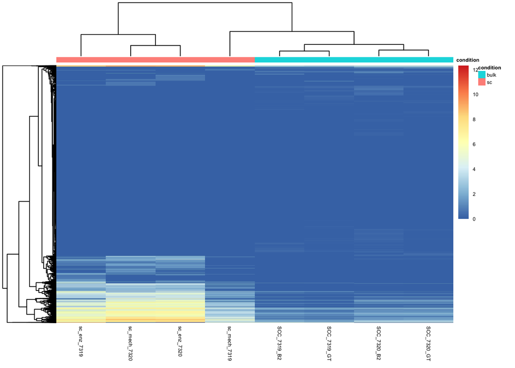

```r
mat <- data.matrix(flat_matrix_ALL)
m_tibble <- meta_data %>%
  rownames_to_column(var="samplename") %>%
  as_tibble()
annotation <- m_tibble %>%data.frame(row.names = "samplename")
mat <-log(mat+1)
pheatmap(mat[1:30000,],
         cluster_rows = T,
         cluster_cols = T,
         show_rownames = F,
         border_color = NA,
         annotation = annotation,
         fontsize = 5)
```